# Part II - Prosper Slide Deck

## by Daniel Chang

## Investigation Overview

**In this investigation, I would like to examine the features of loans that could affect or predict a borrower's APR. Beside my main feature of interest, the APR, I am looking to see how certain variables might affect the APR's relationship with another variable. For example, some relationships that I examined are APR vs. loan amount and APR vs. rating, including the term's effect on the relationship between APR and rating. The categorical variables that I am interested in are: 'LoanStatus', 'IncomeVerifiable', 'EmploymentStatus', 'Term', and 'ProsperRating (Alpha)'. The numeric variables that I am interested in are: 'BorrowerAPR', 'StatedMonthlyIncome', 'LoanOriginalAmount', and 'DebtToIncomeRatio'.**

## Dataset Overview

**This dataset contains 113,937 loans with 81 variables on each loans, including loan amount, borrower rate, current loan status, borrower income, amongst others. The dataset is provided by Prosper via Udacity. While there are a number of data points-799 rows, to be exact- I have chosen not to remove them because I am interested in these anamolies and would like to study them with the dataset.**

## Borrower APR Distribution

**The distribution looks multimodal with small peaks at 0.1 and a bigger one at 0.2. Afterward, it goes on a downward trend with a peak at 0.3 and a sudden spike at 0.35. There are barely any loans above 0.42.**

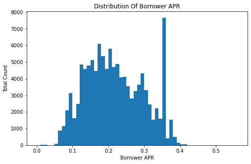

## Heatmap Of Numeric Values

**For this project,the numeric values are: 'BorrowerAPR', 'StatedMonthlyIncome', 'LoanOriginalAmount', and 'DebtToIncomeRatio'**

**From the heatmap, we can see that the correlation coefficient between BorrowerAPR and LoanOriginalAmount is -0.32. The relationship between Debt-to-Income Ratio and Stated Monthly Income is also negatively correlated.Something else we can make out is that the correlation between the original loan amount and stated monthly income is 0.20, meaning that it's positively correlated. This makes sense since the higher the income, the higher the loan you should be able to acquire.**

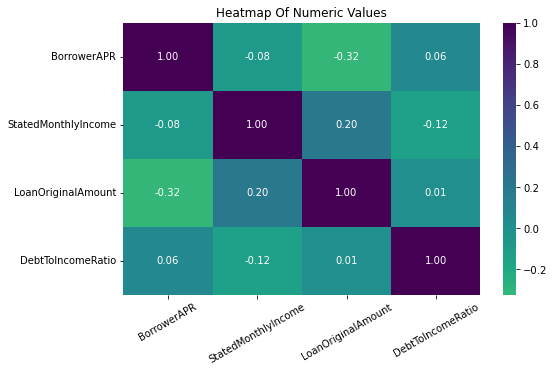

## Loan Amount vs. Borrower APR

**After seeing the heatmap, I want to visualize the relationship between the loan amount and APR, using a scatterplot.**

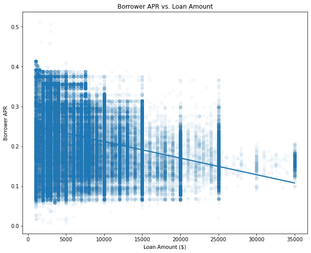

## Effect Of Rating on the Relationship Between APR And Loan Amount

**It seems that an individual's rating has some effect on the relationship between the original loan amount and APR. We can see the relationship gradually turn positive and get stronger as the rating increases.**

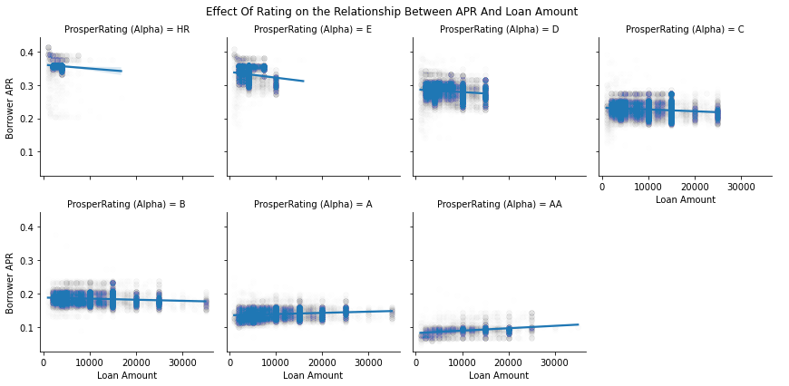

## Borrower APR Across Terms and Ratings

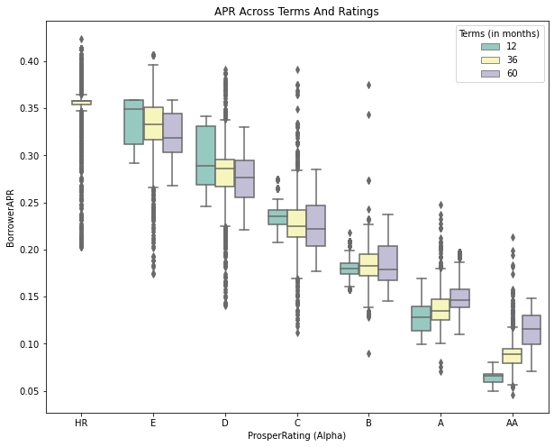